# Exploration of variance in low-probability binomial events

Abhraneel Sarma

2023-05-27

## Introduction

In this document I outline the considerations involved in designing an experiment which tests whether users, in an exploratory visual data analysis scenario, perform multiple comparisons corrections when they are comparing multiple hypotheses. A typical null hypothesis significance test is performed at an $\alpha = 0.05$ which suggests that, one in every 20 “discoveries” using this procedure will be a false discovery. However, in a multiple comparisons procedure, the probability of finding at least one false positive increases as the number of comparisons increases.

### A note on simulations

In this document, we will sample p-values directly, instead of simulating data and then calculating a p-value (for a particular null hypothesis). This speeds up the process (as we do not have to sample random data), and allows greater control over the generated stimuli.

### The distribution of p-value

*When the null is true*: the distribution of the p-value is uniform if the null is true.

```r
# PDF
f_p <- function(x, mu, sigma, K) {
  dnorm(qnorm(1 - x) - sqrt(K) * mu / sigma) / dnorm(qnorm(1 - x))
}
# CDF
F_p <- function(x, mu, sigma, K) {
  1 - pnorm(qnorm(1 - x) - sqrt(K) * mu/sigma)
}
# inverse CDF of p-value
F_p_inv <- function(q, mu, sigma, K, l = 0, u = 1){
  uniroot(function(p) F_p(p, mu, sigma, K) - q, lower = l, upper = u)$root
}
# random sample from PDF of p-value using its invCDF
rp <- function(mu, sigma, K){
  q <- runif(1)
  F_p_inv(q, mu, sigma, K)
}
```

### The probability of a False Positive under multiple comparisons

First, we look at the probability of finding at least one false positive, given the null hypothesis is always true. We first simulate the data, and then plot it. We can also plot the theoretical estimate $(1 - (1 - \alpha)^{\pi_0m}$ to ensure our calculations are correct:

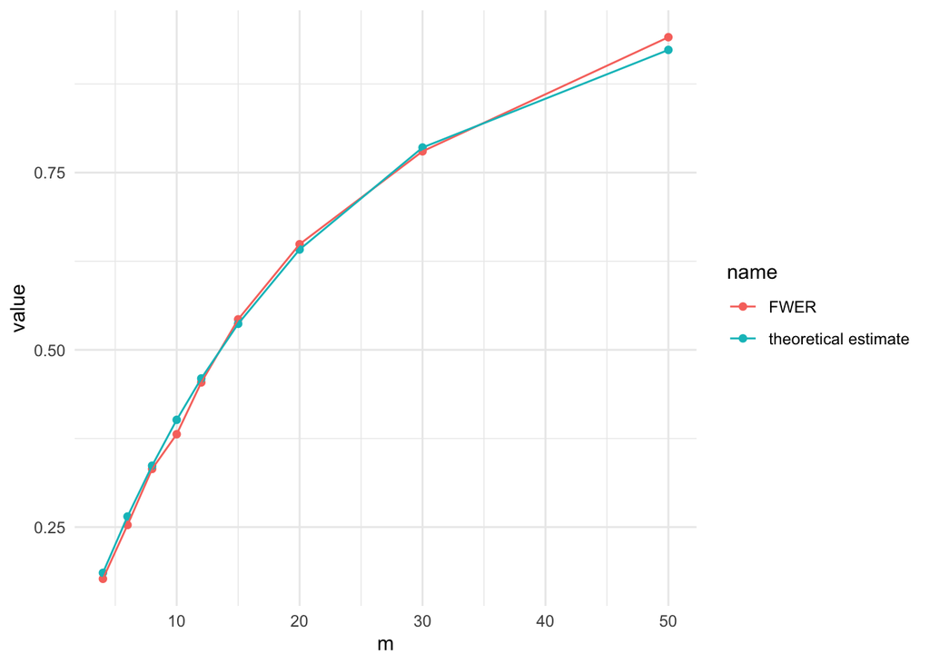

```r
set.seed(1234)
data.sim.pvals = crossing(m, p0 = 1, alpha = 0.05, trial = 1:ntrials) %>%
  mutate(
    `mu > 0` = map2(m, p0, ~ sample(c(rep(0, round(.y * .x)), rep(1, round((1 - .y) * .x))), .x))
  ) %>%
  unnest(c(`mu > 0`)) %>%
  mutate(p = map2_dbl(`mu > 0`, m, ~ ifelse(.x == 0, runif(1, 0, 1), rp(3, 10, .y))))

data.sim.pvals %>%
  mutate(reject_null = p < alpha) %>% # reject or not?
  group_by(m, p0, trial) %>%
  mutate(TP = as.integer(`mu > 0` & reject_null), # correctness of the decision
            FP = as.integer(!`mu > 0` & reject_null),
            TN = as.integer(!`mu > 0` & !reject_null),
            FN = as.integer(`mu > 0` & !reject_null),
  ) %>%
  summarise_at(.vars = vars(TP, FP, TN, FN), sum) %>% # calculates total number of TP, TN, FP, FN for each trial
  # because \pi_0 = 1, here, FDR will always be equal to 1
  # thus correcting for FDR is the same as correcting for FWER
  summarise(FWER = mean(FP > 0), .groups = "drop") %>% # estimates Pr(FP) across the set of trial
  mutate(`theoretical estimate` = 1 - 0.95^m) %>%
  pivot_longer(cols = c(FWER, `theoretical estimate`)) %>%
  ggplot() +
  geom_point(aes(y = value, x = m, color = name)) +
  geom_line(aes(y = value, x = m, color = name))
```

However, the probability of the null being true being equal to one is unrealistic. This can change the probability of finding at least one false positive: